# A Teaching Script for Learning Functions

##### LEARNING BASIC FUNCTIONS IN R

**References:**

[link 1](http://mosaic-web.org/go/Master-Starting.pdf)

[link 2](https://campus.datacamp.com/courses/writing-functions-in-r/a-quick-refresher?ex=1)

[link 3](https://www.datacamp.com/community/tutorials/tutorial-on-loops-in-r#gs.5WuQQ7c)

[link 4](https://www.r-bloggers.com/how-to-write-the-first-for-loop-in-r/)

## Functions:

In R, functions are extremely important. Every command that you run is probably a set of functions that someone else created for you to use. Every package is jammed full of tons of functions that we are able to call with a simple command.

For example, when you type mean(x), R will give you back a number. The only reason it can do this is because the mean() command has been programmed to execute a specific function. Take a look:

```r
smooth.spline
```

[output not shown]

[output cut: 111 more lines]

[output not shown]

```r
# If you run this, you will see the basic syntax of the function that runs when you run the smooth.spline() command, where the function is stored, and what it is named as ("smooth.spline" in this case). Pretty cool!
```

Basically, using and creating functions comes down to two questions:

1. What do we want the computer to do?
   - Tells us which function to use
2. What information does the computer need to compute this?
   - Tells us which arguments we should use

Here are some examples of built-in functions you may have used before in R:

```r
##### Basic calculating functions

sum(6:8)
```

```
## [1] 21
```

```r
mean(1:10)
```

```
## [1] 5.5
```

```r
log(16)
```

```
## [1] 2.772589
```

```r
sqrt(36)
```

```
## [1] 6
```

```r
###### Plotting functions

## Plot info from a sample data set in R: trees
head(trees)
```

```
##   Girth Height Volume
## 1   8.3     70   10.3
## 2   8.6     65   10.3
## 3   8.8     63   10.2
## 4  10.5     72   16.4
## 5  10.7     81   18.8
## 6  10.8     83   19.7
```

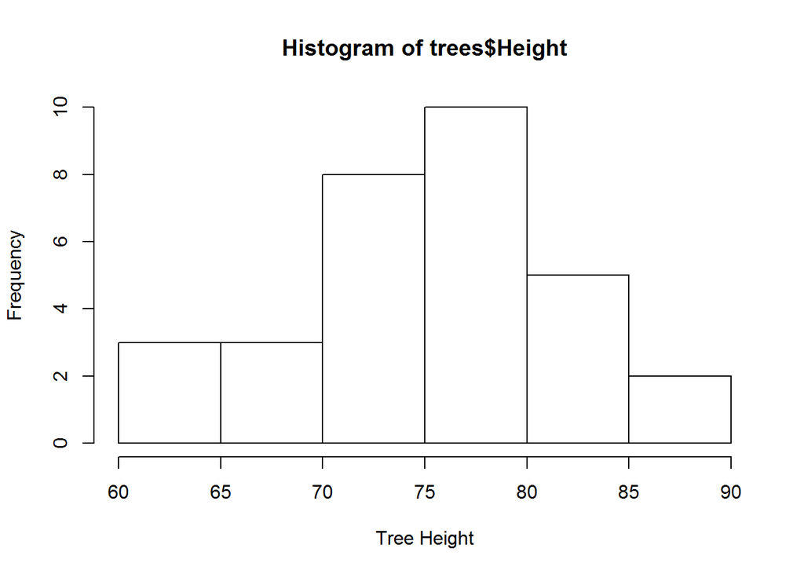

```r
hist(trees$Height,xlab="Tree Height")
```

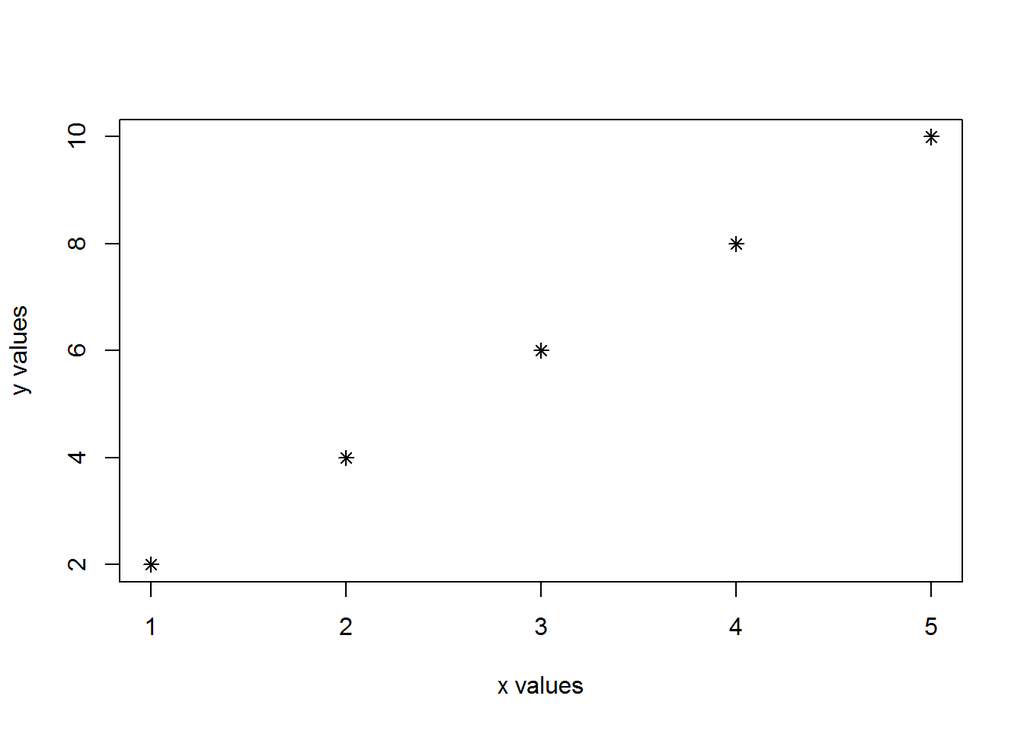

```r
## Plot your own graph
plot(x=c(1,2,3,4,5),y=c(2,4,6,8,10),xlab="x values",ylab="y values",pch=8)
```

```r
###### Statistical functions

## t-test

z<-rnorm(15)
a<-rnorm(15)
t.test(z,a)
```

```
##
##  Welch Two Sample t-test
##
## data:  z and a
## t = -0.53726, df = 23.599, p-value = 0.5961
## alternative hypothesis: true difference in means is not equal to 0
## 95 percent confidence interval:
##  -1.1411305  0.6700712
## sample estimates:
##   mean of x   mean of y
## -0.30995197 -0.07442234
```

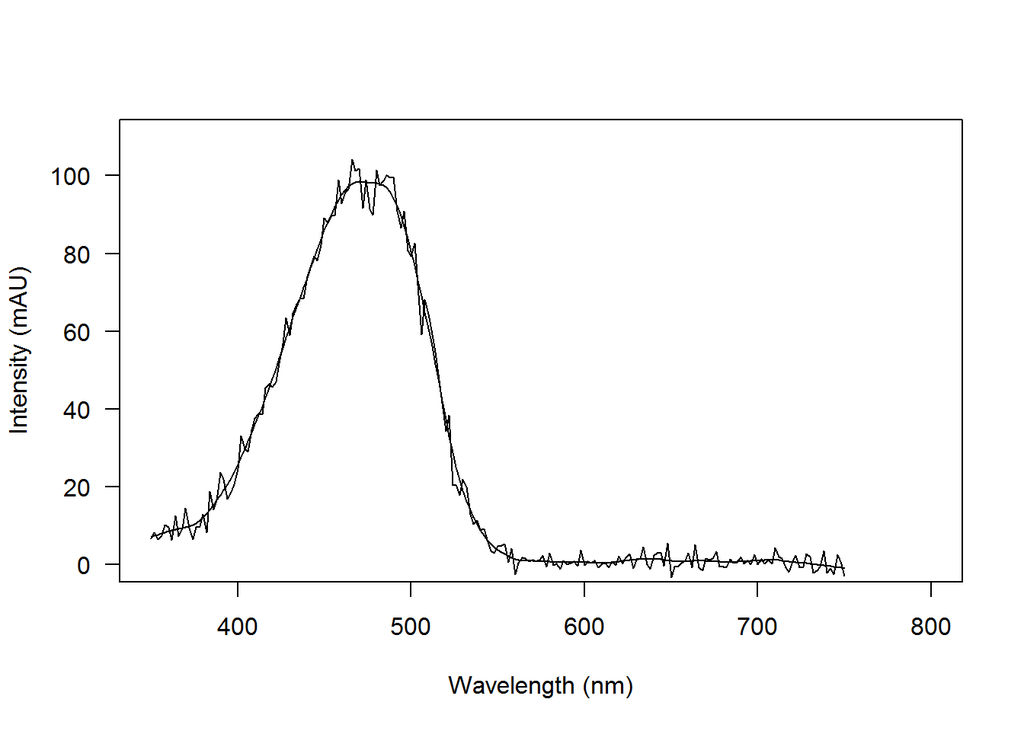

```r
# Look at the results - can you find the p value? Is there a significant difference?

## smooth.spline (fits a cubic smooth line to noisy curves) - one of my favorites!

peak1.standard<-read.csv("Peak1.csv")
# An example of VERY noisy data - unfortunately from my own data
plot(peak1.standard$Wavelength,peak1.standard$mAU,xlim=c(350,800), type="l", pch=1,cex=0.6,las=TRUE,
     ylab="Intensity (mAU)",ylim=c(0,110),xlab="Wavelength (nm)")
# Let's use the smooth.spline function to smooth this line out.
smooth.peak1.standard<-smooth.spline(peak1.standard$Wavelength, peak1.standard$mAU)
# Now plot the smooth line over the noisy line to see how well it fits
plot(peak1.standard$Wavelength,peak1.standard$mAU,xlim=c(350,800), type="l", pch=1,cex=0.6,las=TRUE,
     ylab="Intensity (mAU)",ylim=c(0,110),xlab="Wavelength (nm)")
lines(smooth.peak1.standard)
```

```r
# Remember, these look like simple commands but they are actually functions that have been built into the software for us. Thanks, R!
```

> Luckily, R isn’t too selfish, and it lets you make functions too so let’s give it a shot!